# coverType Data Set - Exploratory Analysis

Brian Carter

24 March, 2015

[figure not shown]

# Introduction

This document presents an exploration of the data contained [Forest CoverType dataset](https://archive.ics.uci.edu/ml/datasets/Covertype) and the creation of a a series of machine model representing the data on the target *coverType* .The R coding environment and **ggplot** was used extensively in data exploration. *(some R code snippets included)*. **Sklean** was the primary package use for model representations.

#### Document Outline

- Data Exploration
  - Data Summary
  - Class Distribution
  - Numerical Data
    - Densities, Boxplots
    - Correlation , Scatterplot
  - Categorical Data
  - Feature Importance
- Points of Interest
- Model Generation with sklearn
  - Five Baseline Models
  - Decision Trees
  - DT with Entropy
  - Grid Search
  - Best Model with Test
  - Functions

## Data Summary

- There are 581012 rows across 55 columns.
- columns 1-10 are quantiative data.
- columns 11-14 are a binary representation of **wilderness_Area**. *(4 columns are mutually exlusive; ComanchePeak, CachePoudre, Neota, Rawah)*
- columns 15-54 are a binary representation of **soilTye**. *(40 columns are mutually exclusive)*
- column **coverType** has 7 values *(target for prediction)*
- The binary columns are mutually exclusive.
- For the purpose of exploratory analysis the binary columns **(wildernessArea, soilType)** are returned to their original form based on information in the **metadata** file.
- In the *covtype.info* file there is extra meta data associated with the **soilType** column that is not in the original dataset.
- Each **soilType** has an unique associated 4-digit *ELU.Code*. The first digit of the *ELU.Code* represents its’ **Climatic Zone** and the second digit its’ **Geological Zone**.
- This extra information is introduced for exploratory analysis.
- There are 581012 rows across 15 columns.
- A summary is presented in Table 1.

| name | dataType | missing | unique | quantity | min | max | mean | std |
| --- | --- | --- | --- | --- | --- | --- | --- | --- |
| Elevation | integer | 0 | 1,978 | meters | 1,859 | 3,858 | 2,959.37 | 279.98 |
| Aspect | integer | 0 | 361 | azimuth | 0 | 360 | 155.66 | 111.91 |
| Slope | integer | 0 | 67 | degrees | 0 | 66 | 14.10 | 7.49 |
| HD.Hydro | integer | 0 | 551 | meters | 0 | 1,397 | 269.43 | 212.55 |
| VD.Hydro | integer | 0 | 700 | meters | -173 | 601 | 46.42 | 58.30 |
| HD.Road | integer | 0 | 5,785 | meters | 0 | 7,117 | 2,350.15 | 1,559.25 |
| HD.Fire | integer | 0 | 207 | meters | 0 | 254 | 212.15 | 26.77 |
| HS.9am | integer | 0 | 185 | 0-255 | 0 | 254 | 223.32 | 19.77 |
| HS.noon | integer | 0 | 255 | 0-255 | 0 | 254 | 142.53 | 38.27 |
| HS.3pm | integer | 0 | 5,827 | 0-255 | 0 | 7,173 | 1,980.29 | 1,324.20 |
| wildernessArea | character | 0 | 4 |  |  |  |  |  |
| soilType | character | 0 | 40 |  |  |  |  |  |
| climaticZone | factor | 0 | 7 |  |  |  |  |  |
| geologicZone | factor | 0 | 4 |  |  |  |  |  |
| coverType | factor | 0 | 7 |  |  |  |  |  |

Table 1: Summary of CoverTye Dataset Featuers

# Class Distribution

The **covtype.info** file includes refences to a number of papers where predictive models were built with **coverType** as the target variable.

```r
#tempTable using dplyr
coverType.cnt = coverData %>%
  group_by(coverType) %>%
  summarise(count=n()) %>%
  mutate(pct=count/sum(count))

plot<-ggplot(coverType.cnt, aes(x=coverType, y=count)) +
  geom_bar(stat="identity") +
  scale_y_continuous(labels=comma) +
  geom_text(data=coverType.cnt, aes(label=count,y=count+30000),size=4) +
  geom_text(data=coverType.cnt, aes(label=paste0(round(pct*100,1),"%"),y=count+10000),size=4) +
  theme_adMobile()

fig_nums("countCT","Distribution of coverType")
```

**coverType** is not evenly distributed. Two classes *(1.SpruceFir, 2.LodgepolePine)* comprise 85% of all rows. Figure 1 displays a bar graphy of **coverType**.

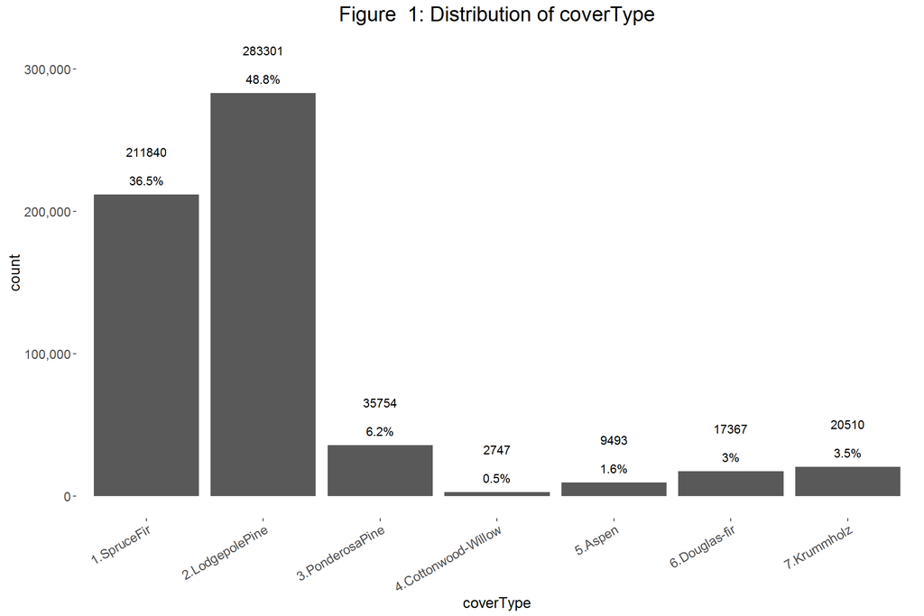

# Numerical Data Exploration

#### Density Plots & Bar Plots

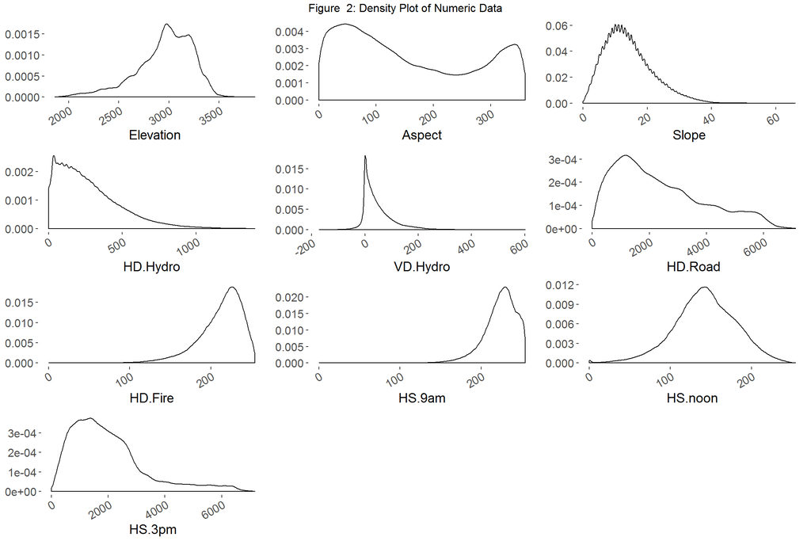

```r
featuresToPlot<-c("Elevation","Aspect","Slope","HD.Hydro","VD.Hydro","HD.Road","HD.Fire","HS.9am","HS.noon","HS.3pm")
p=list()
for(i in 1:length(featuresToPlot)){
  p[[i]] <- ggplot(coverData, aes_string(y=featuresToPlot[i],x="coverType")) +
              geom_boxplot(outlier.shape = NA) +
              theme_adMobile() +
              theme(axis.text.x=element_blank(),axis.title.x=element_blank())

  }
fig_nums("boxNumeric","Boxplot of Numeric Data - coverType")
```

The 10 numeric features are also examined in conjuction with the 7 levels of the **coverType** varaible.

- Outlier points not included *(1.5 inter-quartile range, distance between first and third quartiles)*
- **Elevation** appears to have the biggest class distinctions

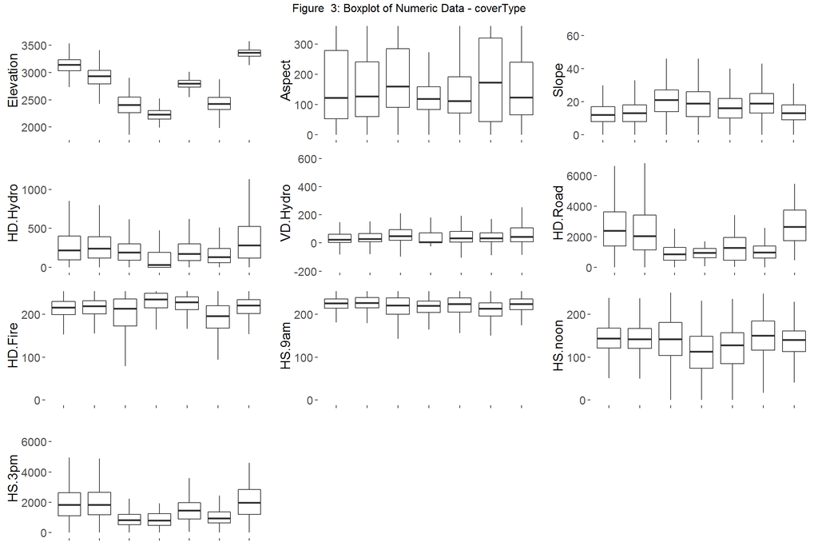

```r
do.call(grid.arrange,c(p,top=eval(fig_nums("boxNumeric"))))
```

# Correlation and Scatterplot

A correlation matrix of the 10 numerical variables is created and plotted in Figure 4

There are six pairwise correlations that have a value higher than absolute 0.5

- HS.9am, HS.noon
- HD.Fire, HS.noon
- HD.Hyrdro, VD.Hyrdo
- Slope, HS.9am
- Aspect, HD.Fire
- Aspect, HS.noon

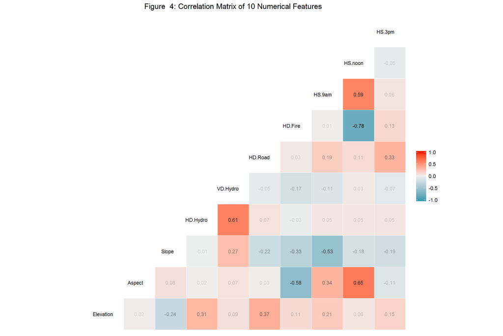

A scatter plot of each combination is presented in Figure 5

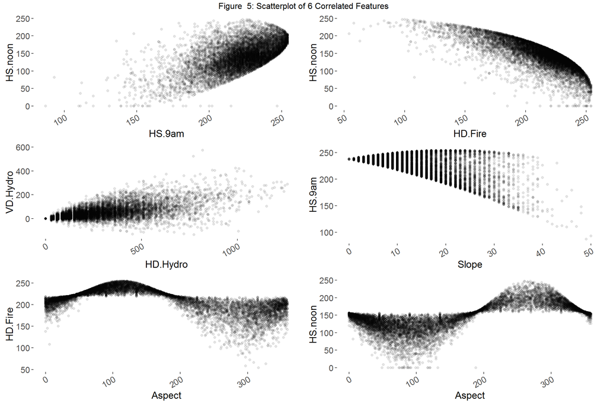

The scatter plot reveals some interesting pairwise relationships.

- A. The hillshade at noon and 9am creates an elipsoid
- C. As the horizontal distance to a hydro increases, the variance in vertical distance increases.
- D. As slope increase a proportion othe data’s hillshade at 9am decreases (probably due to the aspect.)
- E. *HD.Fire* has a sigmoid relationship with *Aspect*
- F. Similarily *Aspect* and *HS.noon* have a more difined sigmoid relationship.

# Categorical Data Exploration

A count of the occurences of the four categorical variables, **wildernessArea, soilType, climaticZone, geologicZone** are plotted in Figure 6.

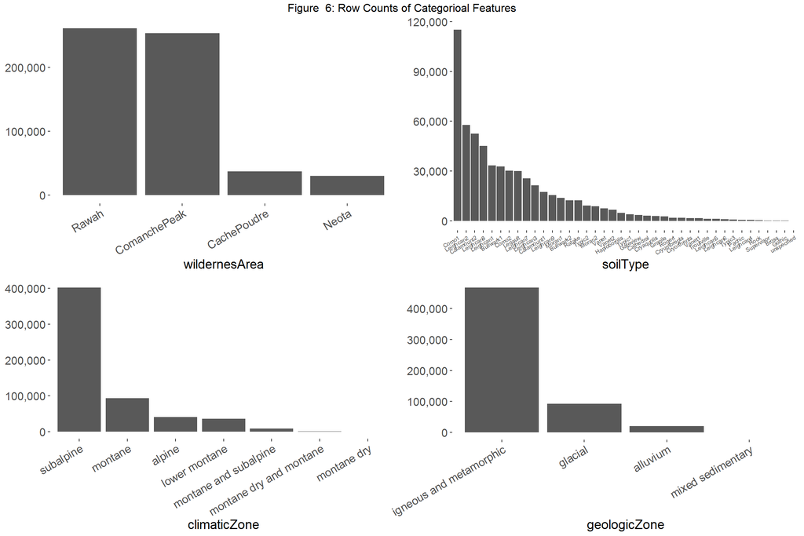

# Feature Importance

- The feature importance of the 15 columns, with respect to *coverType* variable is calculated.
- As expected **Elevation** is the top feature.
- For the *chi-square* measure two of the introduced features, **climaticZone** and **geologicZone** also are in the top 5. *(This may be due to incorrect bucketing of the nuermcical attributes)*
- **Elevation** is also the top feature for *random.forest* feature importance.
- However after that, numerical features are more favoured in contrast to the order for **chi.square** measures.

| features1 | chi.square | features2 | random.forest |
| --- | --- | --- | --- |
| Elevation | 0.477 | Elevation | 1.108 |
| soilType | 0.468 | HS.3pm | 0.852 |
| wildernessArea | 0.443 | HD.Road | 0.817 |
| climaticZone | 0.398 | HD.Hydro | 0.774 |
| geologicZone | 0.175 | VD.Hydro | 0.751 |
| HD.Road | 0.169 | HS.noon | 0.737 |
| HS.3pm | 0.153 | HS.9am | 0.729 |
| Slope | 0.125 | HD.Fire | 0.714 |
| HD.Fire | 0.122 | Aspect | 0.643 |
| HS.noon | 0.098 | wildernessArea | 0.640 |
| HD.Hydro | 0.097 | Slope | 0.598 |
| HS.9am | 0.096 | climaticZone | 0.497 |
| VD.Hydro | 0.081 | geologicZone | 0.419 |
| Aspect | 0.080 | soilType | 0.047 |

Table 2: Feature Importance (chi,randomForest) of CoverTye Dataset Featuers

# Points of Interest

- The target variable is multilabelled
  - Implications for the types of algorithms that can used
  - Implications for the set up of multi-class representation
- Variables are on different scales
  - Rescale variables
- Mixture of numerical and categorical variables
  - Binary representations
  - Clustering requires complex sequence
  - Scale variables to keep 0/1 representation
- There is correlation amoung variables
  - Represents opportunity to reduce the feature set through LDA or PCA?
  - May cause problems for interpretation if required.
  - Complex relationships present, requires to transform variables
- No missing values
- There are negative values
- No outlier analysis completed